# Weekly update for September 11

## Show and Tell September 11

## Upload your progress (using RStudio) 1/2

- Make sure that you connect RStudio and Github. Click [here](http://happygitwithr.com/rstudio-git-github.html).
- Go to File -> New Project -> Version Control -> Git.
- Fill out:

| Field | Address |
| --- | --- |
| Repository URL | https://csafe-isu.github.io/slides |
| Project directory name | slides |
| Create project as subdirectory of | Select with ‘browse’ |

- Go to File -> Open file… -> 02_weekly-updates/update-2017-09-11.Rmd

## Upload your progress (using RStudio) 2/2

- Add a few slides and save. You can copy the format of other slides or make something [more sophisticated](http://rmarkdown.rstudio.com/ioslides_presentation_format.html).
- Click ‘Knit’ button.
- Commit and push your changes on ‘update-2017-09-11.Rmd’ and ‘update-2017-09-11.html’ in the Git section.

## shinyapps repo

The shinyapps repo on github is a sandbox for our different shiny applications:

bulletr, [x3p-viewer](https://x3p-viewer.shinyapps.io/x3p-viewer/), and groove-finder are on there at the moment.

## Shoeprint 1 by Soyoung

- Created database of 150 pairs of shoe print images with 5 reps on each foot.
- The algorithm speeds up and is packed as the package ‘shoeprintr’.
- Toward a final score for similarity between shoe prints.

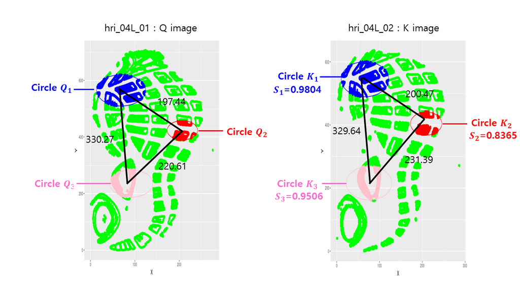

## Shoeprint 2 by Soyoung

- Find more evidence of KM and KNM.

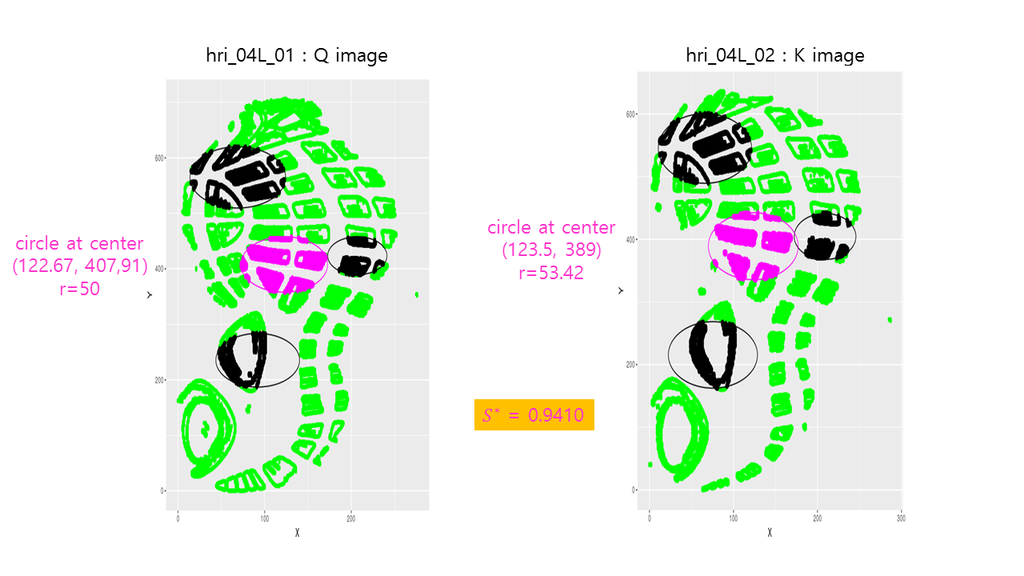

## Jason Saporta

I spent the summer at Credit Suisse making models for predicting loan defaults, prepayments, etc. Not much connection with CSAFE unless you believe everybody on Wall St. is a criminal.

During the past week I implemented a neural network for matching bullet signatures. Everything’s running well, but no serious results yet.

Plans for this week: - Maybe actually getting results for the aforementioned model - Replicating studies on CNN effectiveness for stego problems - Reading more about recent developments in Bayesian ML and determining if that could help with my research

## Amy - Outreach

STEMversity in Milledgeville, GA - 25 high school students  
- One day program  
- Intro, shoe print activity, handwriting activity

OPPTAG Explorations  
- 15 high school students  
- One week program  
- ``From the Crime Scene to the Court Room’’  
- Alicia, Officer Natasha Greene, DCI Crime Lab, Brandon Garrett J.D.